# GLM para dados discretos

Clara Buck

## 1 Introdução

Este relatório apresenta uma análise exploratória e inferencial da abundância de Thunnus albacares (albacora-laje) a partir do banco de dados fisheries.rds. O objetivo é avaliar como fatores ambientais (sst, sal, profundidade e il), sazonais (mês) e pesqueiros (barco, esforço de pesca) influenciam a abundância observada.

A análise segue a abordagem de modelos lineares generalizados (GLM) para dados discretos, testando as distribuições Poisson e Binomial Negativa, com inclusão de um termo de offset para padronizar o esforço de captura.

## 2 Exploração dos dados

Os dados contêm registros de abundância por unidade amostral, variáveis ambientais e metadados de esforço e localidade.

As primeiras etapas incluíram:

## 3 Modelagem da Abundância

### 3.1 Modelo Poisson simples

O primeiro modelo considerou apenas variáveis ambientais:

```r
mod_1 <- glm(Thunnus_albacares ~ sst + sal + depth + il,
data = dados, family = "poisson")

summary(mod_1)
```

```
##
## Call:
## glm(formula = Thunnus_albacares ~ sst + sal + depth + il, family = "poisson",
##     data = dados)
##
## Coefficients:
##               Estimate Std. Error z value Pr(>|z|)
## (Intercept)  2.817e+00  1.660e-01  16.972  < 2e-16 ***
## sst          1.057e-03  6.649e-03   0.159   0.8737
## sal         -4.527e-03  2.638e-03  -1.716   0.0861 .
## depth        7.222e-05  1.273e-05   5.672 1.41e-08 ***
## il           8.922e-03  3.585e-02   0.249   0.8034
## ---
## Signif. codes:  0 '***' 0.001 '**' 0.01 '*' 0.05 '.' 0.1 ' ' 1
##
## (Dispersion parameter for poisson family taken to be 1)
##
##     Null deviance: 6241.0  on 475  degrees of freedom
## Residual deviance: 6201.4  on 471  degrees of freedom
## AIC: 7927.3
##
## Number of Fisher Scoring iterations: 5
```

O valor de dispersão foi maior que 1, indicando sobredispersão, o que torna o modelo de Poisson inadequado para esses dados.

### 3.2 Modelo Poisson com o log de esforço

A inclusão do termo (log(N_anzol)) reduziu a variabilidade residual, mas ainda foi observada sobredispersão:

```r
mod_2 <- glm(Thunnus_albacares ~ sst + sal + depth + il + offset(log(N_anzol)),
data = dados, family = "poisson")


check_overdispersion(mod_2)
```

```
## # Overdispersion test
##
##        dispersion ratio =   14.512
##   Pearson's Chi-Squared = 6834.929
##                 p-value =  < 0.001
```

### 3.3 Modelos com fatores sazonais e pesqueiros

A adição das variáveis Mes (sazonalidade) e Barco (efeito do esforço pesqueiro) melhorou o ajuste de forma progressiva.

```r
mod_4 <- glm(Thunnus_albacares ~ sst + sal + depth + il + Mes + Barco + offset(log(N_anzol)),
data = dados, family = "poisson")

AIC(mod_1, mod_2, mod_4)
```

```
##       df      AIC
## mod_1  5 7927.277
## mod_2  5 7902.545
## mod_4 16 7657.923
```

```r
check_overdispersion(mod_4)
```

```
## # Overdispersion test
##
##        dispersion ratio =   14.225
##   Pearson's Chi-Squared = 6543.290
##                 p-value =  < 0.001
```

### 3.4 Modelo Binomial Negativo

Para contornar a sobredispersão, ajustou-se um modelo Binomial Negativo, que apresentou o melhor desempenho entre os modelos testados.

```r
mod_5 <- MASS::glm.nb(Thunnus_albacares ~ sst + sal + depth + il + Mes + Barco +
offset(log(N_anzol)), data = dados)

AIC(mod_1, mod_2, mod_4, mod_5)
```

```
##       df      AIC
## mod_1  5 7927.277
## mod_2  5 7902.545
## mod_4 16 7657.923
## mod_5 17 3407.458
```

```r
summary(mod_5)
```

```
##
## Call:
## MASS::glm.nb(formula = Thunnus_albacares ~ sst + sal + depth +
##     il + Mes + Barco + offset(log(N_anzol)), data = dados, init.theta = 0.8959294603,
##     link = log)
##
## Coefficients:
##               Estimate Std. Error z value Pr(>|z|)
## (Intercept) -4.289e+00  1.174e+00  -3.655 0.000258 ***
## sst          7.481e-03  3.826e-02   0.196 0.844971
## sal         -7.395e-03  1.139e-02  -0.649 0.516219
## depth        4.898e-05  6.890e-05   0.711 0.477090
## il           5.721e-02  1.419e-01   0.403 0.686855
## Mes         -2.064e-02  1.838e-02  -1.123 0.261345
## BarcoV122    2.157e-01  2.044e-01   1.055 0.291319
## BarcoV170   -1.433e-01  3.266e-01  -0.439 0.660751
## BarcoV192    2.566e-01  3.178e-01   0.807 0.419456
## BarcoV201   -3.030e-01  2.086e-01  -1.452 0.146454
## BarcoV217    3.556e-01  2.594e-01   1.371 0.170415
## BarcoV237   -1.584e-02  2.342e-01  -0.068 0.946086
## BarcoV238   -8.607e-02  2.231e-01  -0.386 0.699628
## BarcoV251    1.194e-01  2.354e-01   0.507 0.612054
## BarcoV266   -1.782e-01  2.067e-01  -0.862 0.388445
## BarcoV348   -4.012e-01  2.595e-01  -1.546 0.122182
## ---
## Signif. codes:  0 '***' 0.001 '**' 0.01 '*' 0.05 '.' 0.1 ' ' 1
##
## (Dispersion parameter for Negative Binomial(0.8959) family taken to be 1)
##
##     Null deviance: 578.53  on 475  degrees of freedom
## Residual deviance: 557.43  on 460  degrees of freedom
## AIC: 3407.5
##
## Number of Fisher Scoring iterations: 1
##
##
##               Theta:  0.8959
##           Std. Err.:  0.0624
##
##  2 x log-likelihood:  -3373.4580
```

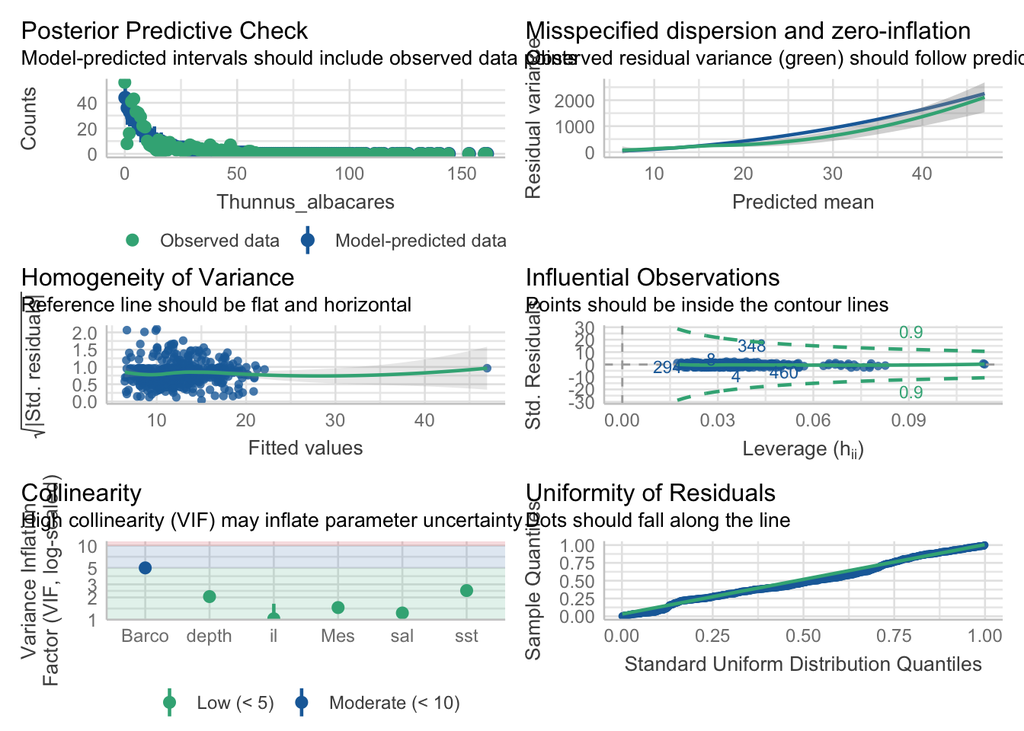

```r
check_model(mod_5)
```

### 3.5 Diagnóstico do Modelo Final

Os resíduos simulados indicam boa aderência dos dados à distribuição ajustada e ausência de padrões sistemáticos.

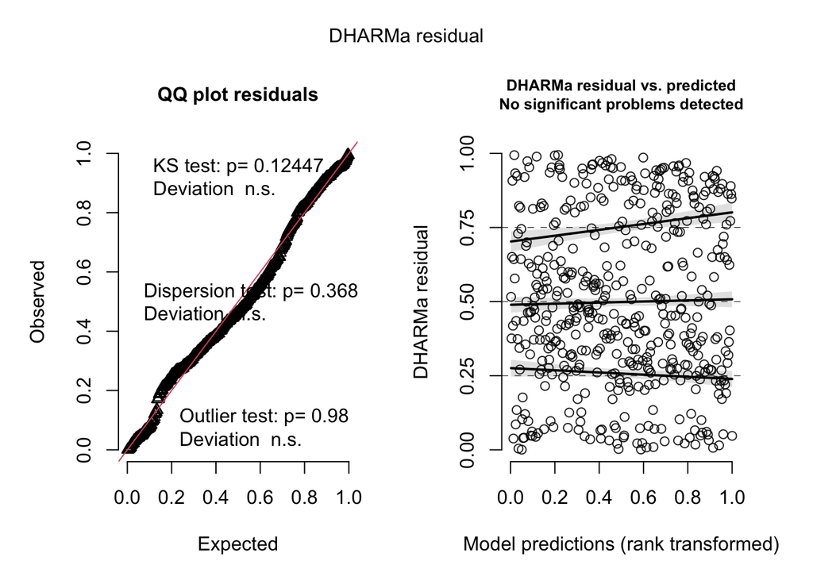

```r
simres <- simulateResiduals(mod_5, n=1000)
plot(simres)
```

## 4 Considerações Finais

Modelos Poisson apresentaram sobredispersão, corrigida pelo uso da Binomial Negativa;

O termo de offset (esforço de pesca) foi essencial para padronizar o esforço amostral;

Alguns pacotes gráficos (GGally, corrplot, ggeffects) apresentaram falhas técnicas, mas não comprometeram as interpretações centrais.